# X and Y: the most harmful events

## Results

#### Across the United States, which types of events are most harmful with respect to population health?

Plot the 10 most harmful type of events with respect to population health.

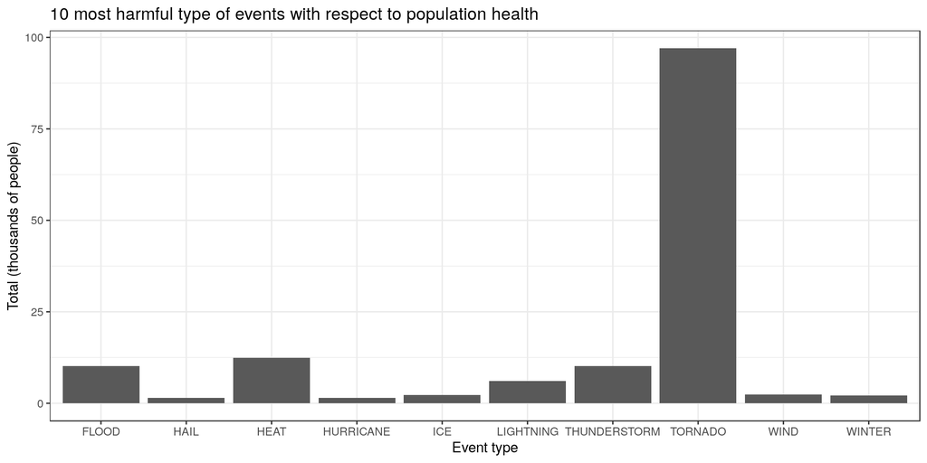

```r
p <- ggplot(head(health_damage, 10), aes(x = EVTYPE2, y = TOTAL/1000)) +
        geom_bar(stat="identity") +
        theme_bw() +
        labs(x = "Event type", y = "Total (thousands of people)", title = "10 most harmful type of events with respect to population health")
print(p)
```

**ANSWER:** TORNADO events are the most harmful type of events with respect to population health.

#### Across the United States, which types of events have the greatest economic consequences?

Plot the 10 most harmful type of events with respect to economic consequences.

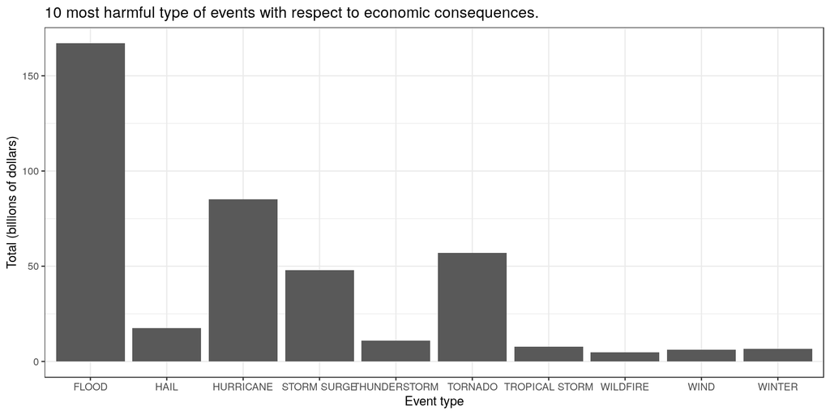

```r
p <- ggplot(head(economic_damage, 10),aes(x = EVTYPE2, y = TOTAL/1000000000)) +
        geom_bar(stat="identity") +
        theme_bw() +
        labs(x = "Event type", y = "Total (billions of dollars)", title = "10 most harmful type of events with respect to economic consequences.")
print(p)
```

**ANSWER:** FLOOD events are the most harmful type of events with respect to economic consequences.